# Análisis Multivariado - Clase 10

## Multidimensional Scaling

## Motivación

Supongamos que un profesor de Análisis Matemático tiene que analizar similitudes entre los rendimientos de los siguientes alumnos según sus puntajes en ejercicios de distintos temas.

```
##          Límite Continuidad Derivada Extremos Integrales Total
## Juan       0.17        1.16     0.78     0.78       0.84  3.73
## Lucas      0.28        0.77     1.26     1.38       1.25  4.94
## Emanuel    0.20        0.85     1.35     1.26       1.56  5.22
## Catalina   0.57        0.47     1.81     0.47       1.76  5.08
## Martín     0.08        0.12     0.80     0.78       1.59  3.37
## Sofía      1.24        0.72     1.68     1.23       0.03  4.90
```

## Distancias Euclídeas

Hay una noción muy simple para ver similaridad entre **las combinaciones** de puntajes, que es calcular la distancia euclídea entre los puntajes. Menores distancias indican mayor similitud.

```
##          Límite Continuidad Derivada Extremos Integrales Total
## Juan       0.17        1.16     0.78     0.78       0.84  3.73
## Lucas      0.28        0.77     1.26     1.38       1.25  4.94
## Emanuel    0.20        0.85     1.35     1.26       1.56  5.22
## Catalina   0.57        0.47     1.81     0.47       1.76  5.08
## Martín     0.08        0.12     0.80     0.78       1.59  3.37
## Sofía      1.24        0.72     1.68     1.23       0.03  4.90
```

```
##               Juan     Lucas   Emanuel  Catalina    Martín
## Lucas    1.5449272
## Emanuel  1.8414125 0.4580393
## Catalina 2.1123447 1.2587295 1.0847119
## Martín   1.3349906 1.9012101 2.1221687 2.1051841
## Sofía    2.0918891 1.6164777 1.9109160 2.0325354 2.7307508
```

## Objetivos

El problema es que no podemos ver gráficamente estas similitudes y diferencias, dado que tenemos un número elevado de variables.

A su vez, si el número de observaciones es muy grande, la matriz de distancias tampoco es fácil de analizar.

Por lo tanto, vamos a tratar de representar la información de las distancias en un espacio de menor dimensión que sí podamos analizar gráficamente.

## Matrices utilizadas

- Consideremos \(D\) la matriz de distancias.
- Se calcula la matriz \(A=-\frac{1}{2}D^{2}\), donde \(D^2\) representa los cuadrados de las distancias de la matriz \(D\).
- Una matriz \(H\) que logra centrar cualquier matriz por filas o columnas: \[H=\begin{pmatrix}1-\frac{1}{n} & -\frac{1}{n} & \cdots & -\frac{1}{n}\\-\frac{1}{n} & 1-\frac{1}{n} & \cdots & -\frac{1}{n} \\\vdots & \vdots & \ddots & \vdots \\-\frac{1}{n} & -\frac{1}{n} & \cdots & 1-\frac{1}{n} \\\end{pmatrix}\]

## Matriz de producto interno

- La matriz que se termina utilizando es \(B=H\times A \times H\). Es decir, la matriz de distancias euclídeas al cuadrado centrada por filas y columnas.
- Se puede demostrar que la matriz \(B\) tiene todos sus autovalores positivos o nulos. Es decir, en la diagonalización de esta matriz, la matriz diagonal \(\Lambda\) tiene todos sus valores positivos o nulos: \[B=\underset{n\times n}{\underbrace{\Gamma}} \times \underset{n\times n}{\underbrace{\Lambda}} \times \underset{n\times n}{\underbrace{\Gamma^T}}\]
- Por último, se puede reducir la dimensión de la matriz \(B\) utilizando los primeros \(k\) autovalores y autovectores: \[B_k=\underset{n\times k}{\underbrace{\Gamma_k}} \times \underset{k\times k}{\underbrace{\Lambda_k}} \times \underset{k\times n}{\underbrace{\Gamma_k^T}}\]
- Las coordenadas de similitud se representan en una matriz \(X\), donde \(B=X\times X^T\) y \(X=\Gamma_k \times \Lambda_k^{\frac{1}{2}}\)

## Cantidad de dimensiones

Los autovalores de la matriz \(B\) representan la variabilidad en las distancias. Entonces, del mismo modo que en metodologías anteriores, se puede buscar explicar un porcentaje de la varianza entre las distancias:

- Autovalores:

```
## [1]  4.329550e+00  2.581651e+00  9.745454e-01  4.091094e-01  3.776333e-04
## [6] -9.997624e-17
```

- Proporción de varianza explicada:

```
## [1] 0.5219323 0.8331533 0.9506359 0.9999545 1.0000000 1.0000000
```

En este caso, estaría bien tomar 2 dimensiones para representar las distancias.

## Reducción de la dimensión

```
##          Dimensión1  Dimensión2
## Juan      0.8286200  0.62992769
## Lucas    -0.3145756 -0.19081000
## Emanuel  -0.4548552 -0.59429501
## Catalina -0.4345005 -0.82570277
## Martín    1.4281934 -0.07187615
## Sofía    -1.0528821  1.05275624
```

## Mapa de similaridad

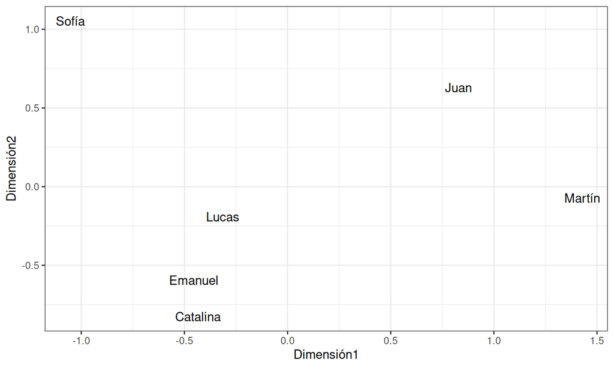

## Mapa de similaridad (Total)

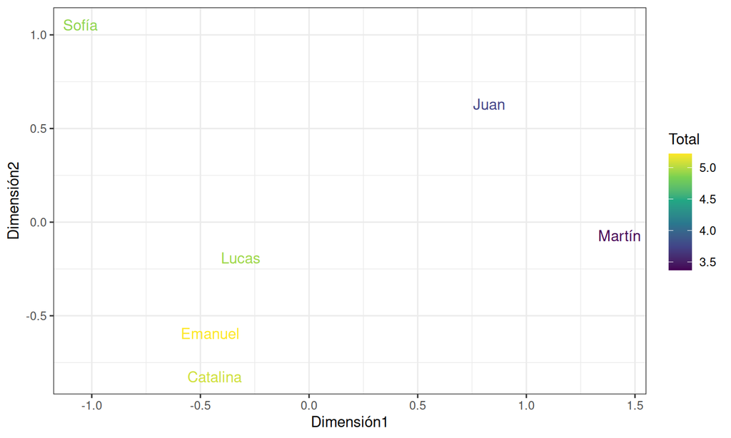

## Mapa de similaridad (Continuidad)

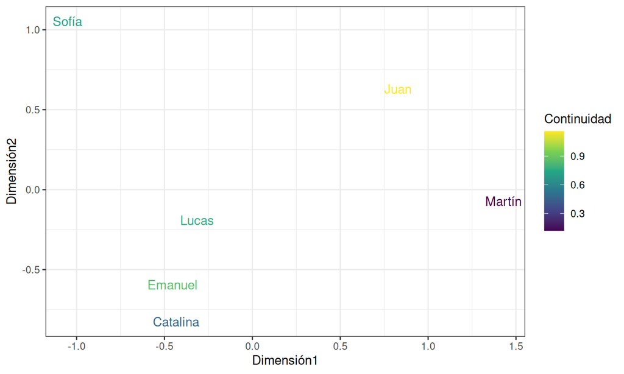

## Mapa de similaridad (Derivada)

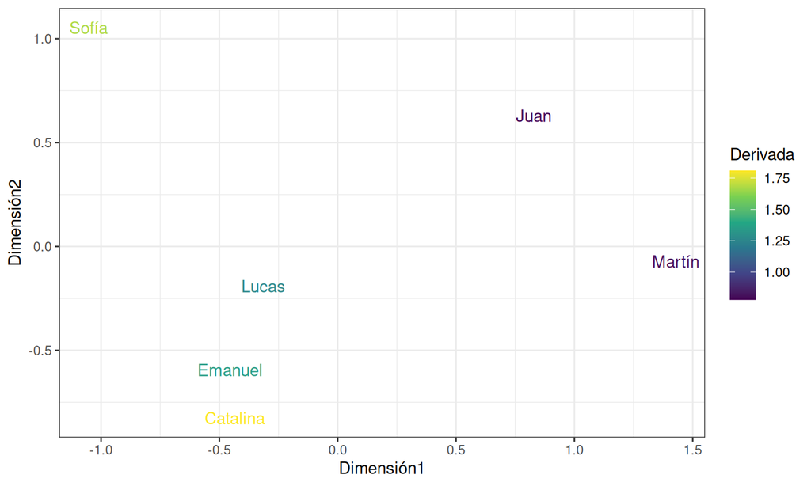

## Mapa de similaridad (Integrales)

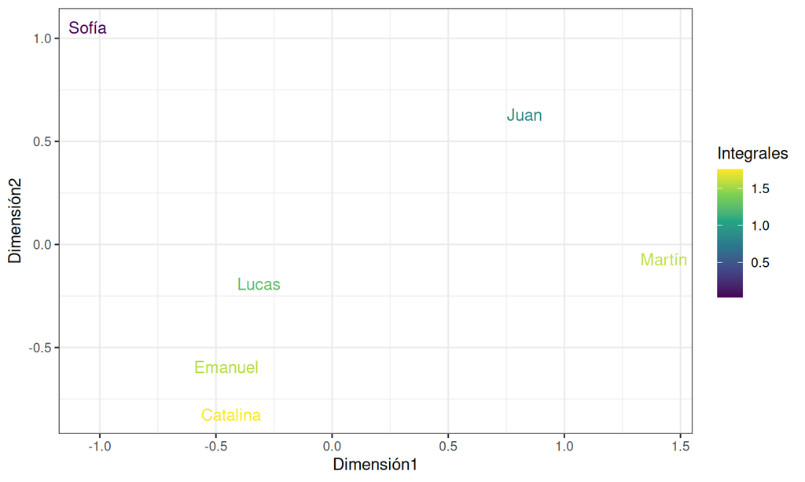

## Datos completos

```
## 'data.frame':    154 obs. of  6 variables:
##  $ Límite     : num  0.17 0.28 0.2 0.57 0.08 1.24 0.83 0.89 0 0.37 ...
##  $ Continuidad: num  1.16 0.77 0.85 0.47 0.12 0.72 0.72 0.53 1.06 0 ...
##  $ Derivada   : num  0.78 1.26 1.35 1.81 0.8 1.68 2 1.52 0.26 0.66 ...
##  $ Extremos   : num  0.78 1.38 1.26 0.47 0.78 1.23 1 0.41 1.64 0.91 ...
##  $ Integrales : num  0.84 1.25 1.56 1.76 1.59 0.03 0.23 1.67 1.44 1.14 ...
##  $ Total      : num  3.73 4.94 5.22 5.08 3.37 4.9 4.78 5.02 4.4 3.08 ...
```

## Varianza explicada

- Autovalores:

```
## [1] 1.128897e+02 1.008042e+02 4.253436e+01 1.768587e+01 1.423279e+01
## [6] 7.153990e-15
```

- Proporción Varianza Explicada:

```
## [1] 0.3917783 0.7416144 0.8892278 0.9506058 1.0000000 1.0000000
```

## Mapa de similaridad (Componente 1 vs. Componente 2)

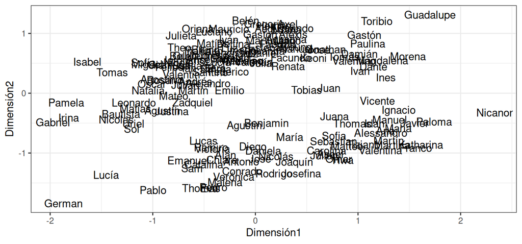

```
##         Límite Continuidad Derivada Extremos Integrales Total
## Gabriel   0.85        0.69     2.00     1.78       0.60  5.92
## Nicanor   0.22        0.14     0.17     0.41       1.53  2.47
```

## Mapa de similaridad (Componente 1 vs. Componente 2)

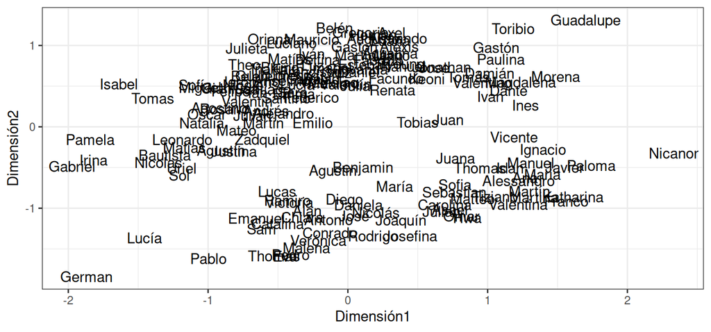

```
##        Límite Continuidad Derivada Extremos Integrales Total
## Belén    1.69        1.15     0.69     0.64          0  4.17
## Malena   0.42        0.24     1.70     0.61          2  4.97
```

## Mapa de similaridad (Componente 1 vs. Componente 3)

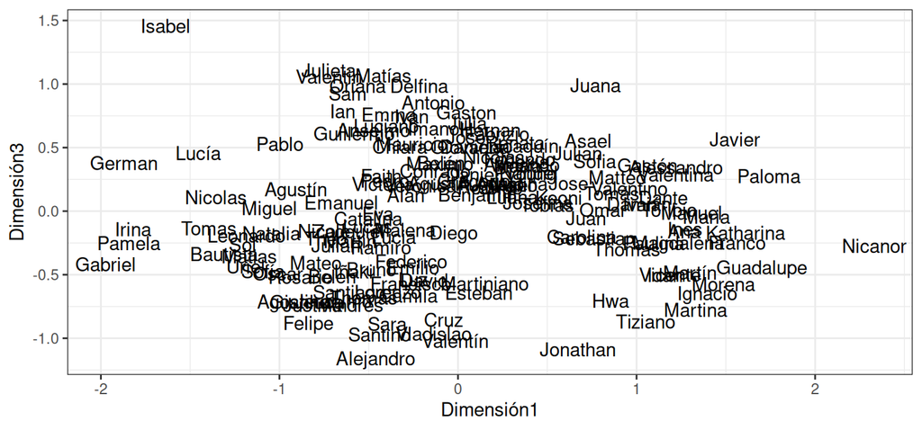

```
##          Límite Continuidad Derivada Extremos Integrales Total
## Juana      0.85        1.01     0.00     0.66       1.63  4.15
## Jonathan   0.45        0.52     1.29     0.97       0.00  3.23
```

## Mapa de similaridad (Componente 2 vs. Componente 3)

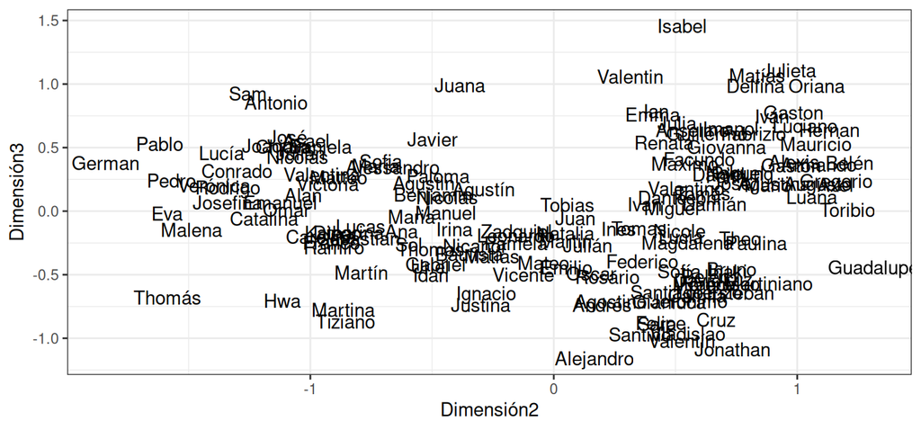

```
##         Límite Continuidad Derivada Extremos Integrales Total
## Juana     0.85        1.01     0.00     0.66       1.63  4.15
## Justina   0.42        0.60     1.78     1.44       0.60  4.84
```

## Mapa de similaridad (Componente 1 vs. Componente 2 - Puntaje total)

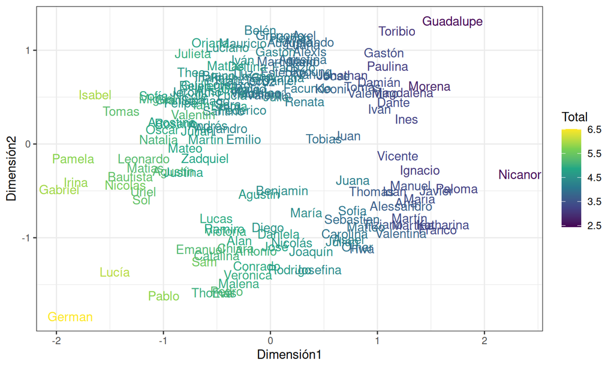

## Mapa de similaridad (Componente 1 vs. Componente 2 - Integrales)

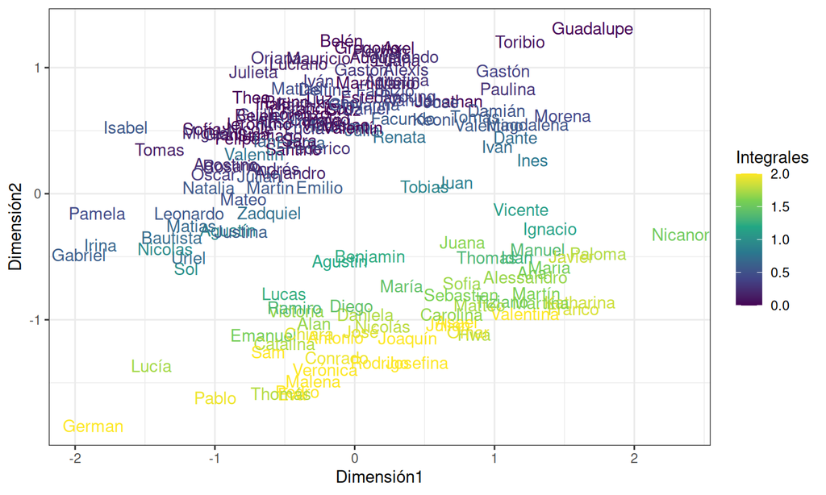

## Mapa de similaridad (Componente 2 vs. Componente 3 - Derivada)

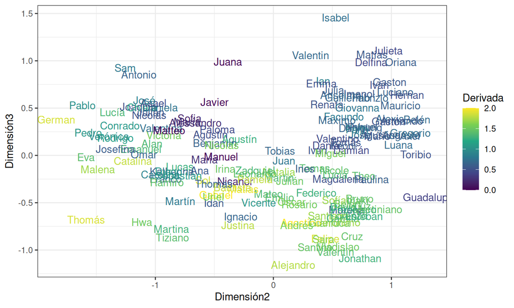

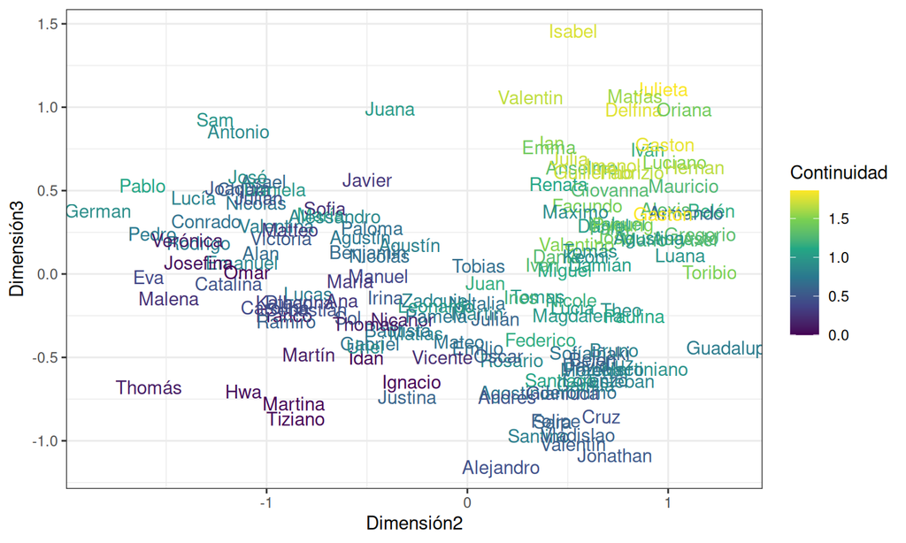

## Ponderación de diferencias euclídeas

Prioridad a las diferencias en Puntaje, Derivadas e Integrales

Diferencias anteriores

```
##              Juan     Lucas   Emanuel Catalina   Martín
## Juan     0.000000 1.5449272 1.8414125 2.112345 1.334991
## Lucas    1.544927 0.0000000 0.4580393 1.258730 1.901210
## Emanuel  1.841413 0.4580393 0.0000000 1.084712 2.122169
## Catalina 2.112345 1.2587295 1.0847119 0.000000 2.105184
## Martín   1.334991 1.9012101 2.1221687 2.105184 0.000000
```

Diferencias actuales

```
##               Juan     Lucas   Emanuel  Catalina    Martín
## Juan     0.0000000 0.8077803 0.9951884 1.0373393 0.4985342
## Lucas    0.8077803 0.0000000 0.2234441 0.4478027 1.0151802
## Emanuel  0.9951884 0.2234441 0.0000000 0.3676708 1.1706447
## Catalina 1.0373393 0.4478027 0.3676708 0.0000000 1.1383042
## Martín   0.4985342 1.0151802 1.1706447 1.1383042 0.0000000
```

## Selección de k

Primeros autovalores:

```
## [1] 3.451880e+01 1.612064e+01 6.168825e+00 1.711683e+00 1.459216e+00
## [6] 1.173515e-14
```

Proporción Varianza Acumulada:

```
## [1] 0.5755131 0.8442839 0.9471333 0.9756713 1.0000000 1.0000000
```

## Mapa similaridad

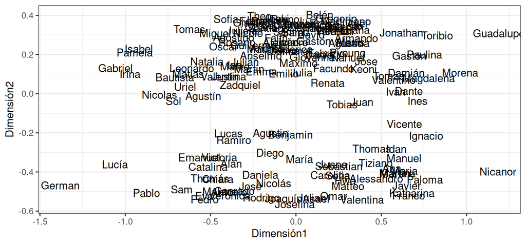

```
##           Límite Continuidad Derivada Extremos Integrales Total
## Nicanor     0.22        0.14     0.17     0.41       1.53  2.47
## German      0.34        0.92     1.87     1.38       2.00  6.51
## Guadalupe   0.80        0.77     0.38     0.49       0.00  2.44
```

## Mapa similaridad (Puntaje Total)

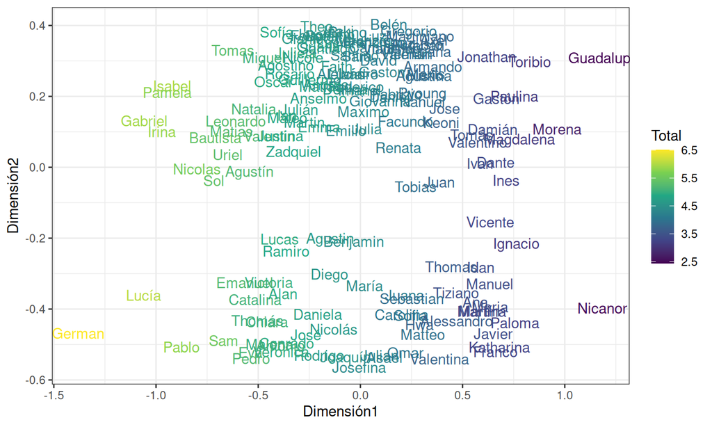

## Mapa similaridad (Integrales)

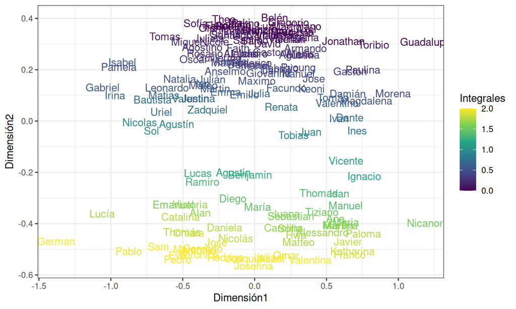

## Manhattan

Hasta ahora, hemos utilizado variantes de la distancia euclídea. Sin embargo, podemos utilizar otras funciones de distancia para calcular la matriz \(D\). Por ejemplo, podemos utilizar la distancia manhattan:

```
##          Juan Lucas Emanuel Catalina Martín Sofía
## Juan     0.00  3.20    3.60     4.70   2.26  4.84
## Lucas    3.20  0.00    0.96     2.70   3.82  2.84
## Emanuel  3.60  0.96    0.00     2.34   3.76  3.38
## Catalina 4.70  2.70    2.34     0.00   4.04  3.72
## Martín   2.26  3.82    3.76     4.04   0.00  6.18
## Sofía    4.84  2.84    3.38     3.72   6.18  0.00
```

## Autovalores

Sin embargo, si observamos los autovalores, se observa algo distinto:

Primeros Autovalores:

```
## [1] 495.38341 451.18521 174.48611  93.00318  69.77147  47.30757
```

“Varianza explicada”:

```
## [1] 0.4131238 0.7893886 0.9349008 1.0124606 1.0706463 1.1100984
```

Últimos Autovalores:

```
## [1] -16.71520 -17.86231 -22.02247 -26.86499 -35.13219 -67.34258
```

“Varianza explicada”:

```
## [1] 1.141124 1.126228 1.107863 1.085459 1.056160 1.000000
```

## Distancias No Euclídeas

En casos en los que la distancia no es euclídea, se genera este problema en los autovalores de la matriz \(B\): Aparecen autovalores negativos. Por lo tanto, se pueden adoptar los distintos criterios para seleccionar \(k\).

## Criterios

Sólo Autovalores positivos \(\dfrac{\displaystyle{\sum_{i=1}^k }\lambda_i}{\displaystyle{\sum_{i\,/\,\lambda_i>0} }\lambda_i}\)

```
## [1] 0.3020788 0.5772060 0.6836055 0.7403178 0.7828636 0.8117111
```

## Criterios

Cuadrados \(\dfrac{\displaystyle{\sum_{i=1}^k }\lambda_i^2}{\displaystyle{\sum_{i=1}^n }\lambda_i^2}\)

```
## [1] 0.4813034 0.8805541 0.9402656 0.9572297 0.9667773 0.9711666
```

## Criterios

Módulos \(\dfrac{\displaystyle{\sum_{i=1}^k }|\lambda_i|}{\displaystyle{\sum_{i=1}^n }|\lambda_i|}\)

```
## [1] 0.2380835 0.4549251 0.5387839 0.5834817 0.6170142 0.6397504
```

## Criterios adicionales

Se compara el autovalor negativo de mayor magnitud \(\begin{vmatrix} \lambda_{\text{min}} \end{vmatrix}\) con el autovalor positivo de mayor magnitud \(\lambda_1\): \[\text{Ratio} = \frac{\vert{}\lambda_{\text{min}}\vert{}}{\lambda_1}\]

- Si la proporción es muy pequeña (\(< 0.05\) ó \(5\%\)): Los valores negativos provienen de ruido en los datos o pequeños errores de redondeo. Se pueden ignorar y truncar la solución reteniendo solo los mayores \(\lambda_i > 0\).
- Si la proporción es significativa (\(> 0.15\) ó \(15\%\)): La no-euclidianidad de los datos es severa. Ignorar los componentes negativos distorsionará fuertemente las distancias reales.

En este caso,

```
## [1] 0.1359403
```

## Criterios adicionales

\[\small \text{Proporción Negativa} = \frac{\sum_{\lambda_j < 0} \vert{}\lambda_j\vert{}}{\sum_{\lambda_i > 0} \lambda_i}\]

- \(< 0.05\) (menor al 5%): El conjunto total de dimensiones no euclidianas es residual. Se pueden descartar todos los autovalores negativos sin afectar significativamente las relaciones geométricas.
- \(> 0.15\) (mayor al 15%): El impacto acumulado de los autovalores negativos es alto. Ignorarlos distorsiona severamente la representación espacial.

En este caso

```
## [1] 0.2687935
```

## Criterios adicionales

\[\small \text{Proporción Negativa Total} = \frac{\sum_{\lambda_j < 0} \vert{}\lambda_j\vert{}}{\sum_{i=1}^{n} \vert{}\lambda_i\vert{}}\]

- \(< 0.05\) (menor al 5%): El conjunto total de dimensiones no euclidianas es residual. Se pueden descartar todos los autovalores negativos sin afectar significativamente las relaciones geométricas.
- \(> 0.15\) (mayor al 15%): El impacto acumulado de los autovalores negativos es alto. Ignorarlos distorsiona severamente la representación espacial.

En este caso:

```
## [1] 0.2118497
```

## Mapa de similaridad (Componente 1 vs. Componente 2)

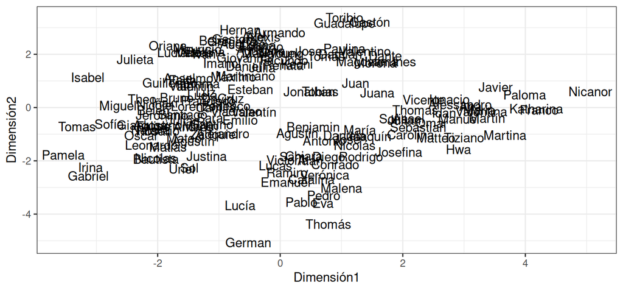

```
##         Límite Continuidad Derivada Extremos Integrales Total
## Isabel    2.00        1.75     0.73     0.93       0.55  5.96
## Nicanor   0.22        0.14     0.17     0.41       1.53  2.47
```

## Mapa de similaridad (Componente 1 vs. Componente 2)

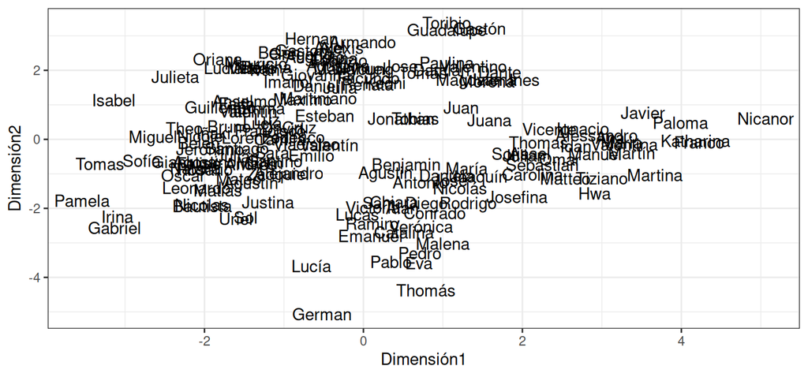

```
##        Límite Continuidad Derivada Extremos Integrales Total
## German   0.34        0.92     1.87     1.38       2.00  6.51
## Hernan   1.20        1.66     0.49     0.56       0.16  4.07
```

## Mapa de similaridad (Componente 1 vs. Componente 3)

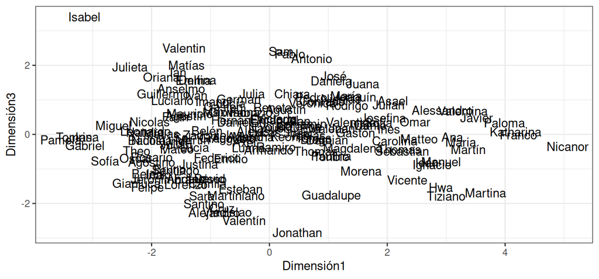

```
##          Límite Continuidad Derivada Extremos Integrales Total
## Sara       0.67        0.61     1.63     1.25       0.08  4.24
## Jonathan   0.45        0.52     1.29     0.97       0.00  3.23
```

## Mapa de similaridad (Componente 2 vs. Componente 3)

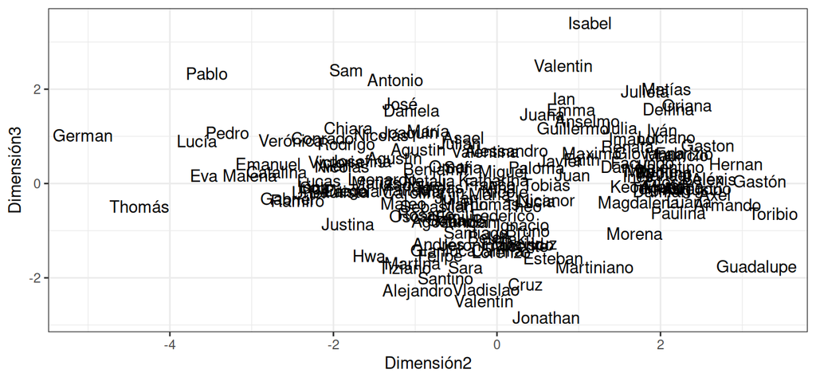

```
##          Límite Continuidad Derivada Extremos Integrales Total
## Isabel     2.00        1.75     0.73     0.93       0.55  5.96
## Jonathan   0.45        0.52     1.29     0.97       0.00  3.23
```

## Variables Categóricas

El uso más extendido de multidimensional scaling es para buscar similitudes entre combinaciones de variables categóricas.

```
##          Límite Continuidad Derivada Extremos Integrales
## Juan         M+          R+        R        R          R
## Lucas       R--           R      B--      B--         R+
## Emanuel      M+           R      B--      B--        B--
## Catalina     R-         R--       B-      R--         B-
## Martín        M          M+        R        R        B--
## Sofía        R+          R-       B-       R+          M
```

## Disimilaridad

Para lograrlo, se busca ordenar las observaciones de menor a mayor según su disimilaridad.

```
##          Límite Continuidad Derivada Extremos Integrales
## Juan         M+          R+        R        R          R
## Lucas       R--           R      B--      B--         R+
## Emanuel      M+           R      B--      B--        B--
## Catalina     R-         R--       B-      R--         B-
## Martín        M          M+        R        R        B--
## Sofía        R+          R-       B-       R+          M
```

```
##          Juan Lucas Emanuel Catalina Martín Sofía
## Juan        0     2       3       11      4    14
## Lucas       2     0       1        6      7    10
## Emanuel     3     1       0        8      5    12
## Catalina   11     6       8        0      9    13
## Martín      4     7       5        9      0    15
## Sofía      14    10      12       13     15     0
```

## Non-Metric MDS

En el caso de tener un ranking de disimilitudes (se suelen llamar \(\delta_{i,j}\)), se busca transformar el problema al escenario anterior. Es decir, generar una función de distancia \(d_{i,j}\) en el que se pueda aplicar el escalado ya visto, pero con una función de distancia menos rígida.

Esta función debe ser monótona, en el sentido de que a mayor disimilitud, mayor debe ser la distancia. Es decir, si \(\delta_{i,j}\le \delta_{i',j'}\Rightarrow d_{i,j}\le d_{i',j'}\).

## Inicialización

Para lograr coordenadas numéricas que puedan reflejar la similaridad, se comienza con valores aleatorios para cada observación:

```
##                  x1           x2
## Juan      1.2629543 -0.928567035
## Lucas    -0.3262334 -0.294720447
## Emanuel   1.3297993 -0.005767173
## Catalina  1.2724293  2.404653389
## Martín    0.4146414  0.763593461
## Sofía    -1.5399500 -0.799009249
```

## Ranking Distancias

La función de distancias generada debería seguir el mismo orden que las disimilitudes.

```
##                 par rank_disi      dist rank_dist
## 1        Juan-Lucas         2 1.7109292         6
## 2      Juan-Emanuel         3 0.9252177         1
## 3     Juan-Catalina        11 3.3332339        14
## 4       Juan-Martín         4 1.8928925         8
## 5        Juan-Sofía        14 2.8058970        11
## 6     Lucas-Emanuel         1 1.6810527         5
## 7    Lucas-Catalina         6 3.1372506        13
## 8      Lucas-Martín         7 1.2918683         3
## 9       Lucas-Sofía        10 1.3143118         4
## 10 Emanuel-Catalina         8 2.4111032         9
## 11   Emanuel-Martín         5 1.1955876         2
## 12    Emanuel-Sofía        12 2.9773636        12
## 13  Catalina-Martín         9 1.8517229         7
## 14   Catalina-Sofía        13 4.2629722        15
## 15     Martín-Sofía        15 2.5024298        10
```

## Pool Adjacent Vectors

Es decir, este gráfico debería estar sobre la recta \(y=x\):

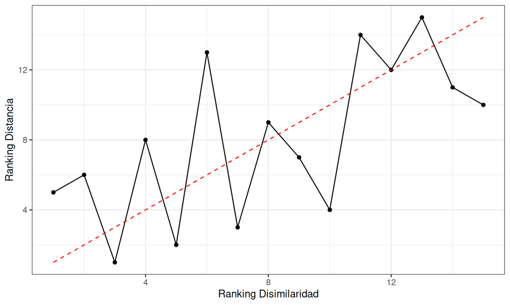

## STRESS

Una medida para ver si la representación es buena se denomina STRESS y se calcula de la siguiente manera: \[\text{STRESS}_1=\left(\dfrac{\sum_{i<j}(d_{i,j}-\widehat{d}_{i,j})^2}{\sum_{i<j} d_{i,j}^ 2}\right)^{\frac{1}{2}}\] El algoritmo va cambiando las distancias para que queden en el orden correcto y buscando reducir esta medida hasta que converge. Al converger, se calcula el valor de STRESS:

- Valores por debajo de 0.05 indican una representación ideal.
- Valores entre 0.05 y 0.1 indican una buena representación.
- Valores entre 0.1 y 0.2 indican una representación que permite sacar conclusiones, pero con cautela.
- Valores mayores a 0.2 indican una mala representación.

## Non-Metric MDS

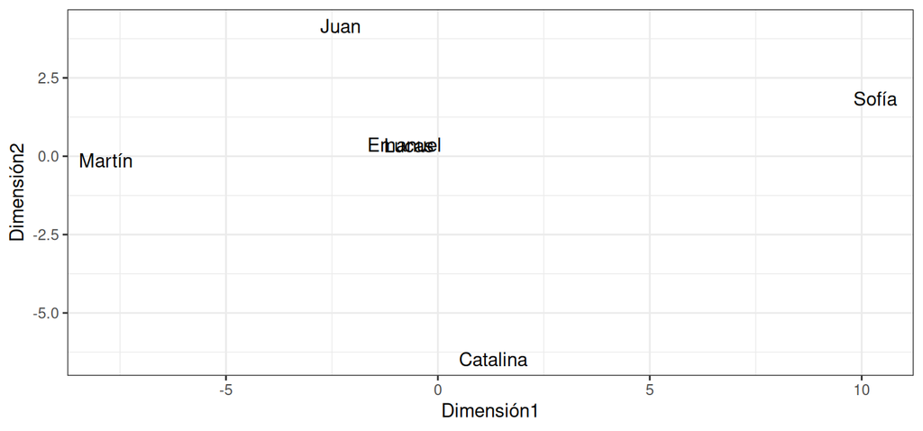

```
##        Límite Continuidad Derivada Extremos Integrales
## Martín      M          M+        R        R        B--
## Sofía      R+          R-       B-       R+          M
```

## Non-Metric MDS

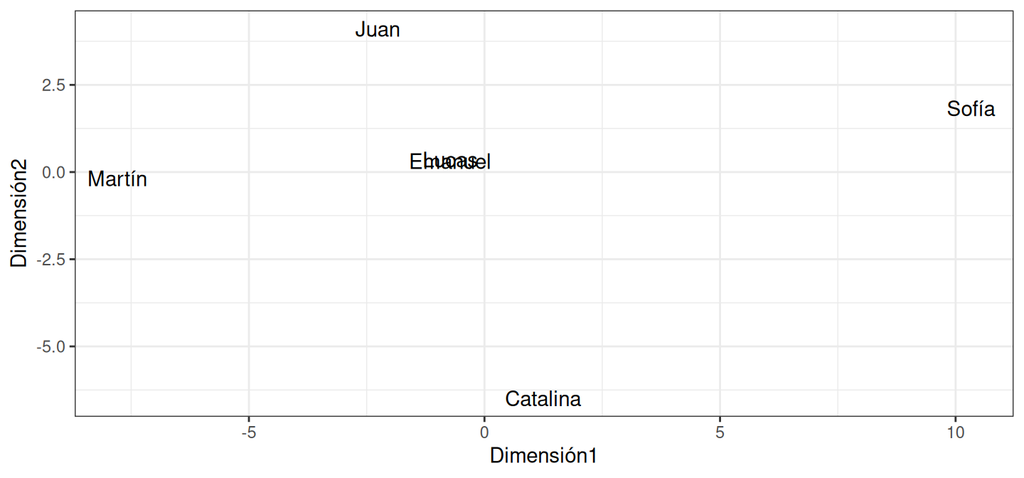

```
##          Límite Continuidad Derivada Extremos Integrales
## Catalina     R-         R--       B-      R--         B-
## Juan         M+          R+        R        R          R
```

## Non-Metric MDS

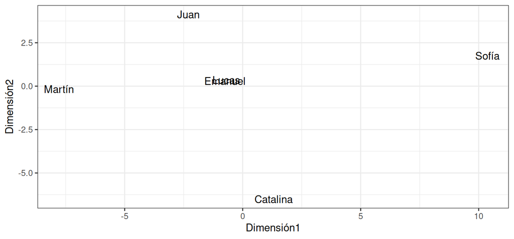

La medida de STRESS es:

```
## [1] 0.009230364
```

## Datos Completos

```
## 'data.frame':    154 obs. of  5 variables:
##  $ Límite     : Ord.factor w/ 9 levels "M"<"M+"<"R--"<..: 2 3 2 4 1 6 5 5 1 3 ...
##  $ Continuidad: Ord.factor w/ 9 levels "M"<"M+"<"R--"<..: 6 5 5 3 2 4 4 4 6 1 ...
##  $ Derivada   : Ord.factor w/ 9 levels "M"<"M+"<"R--"<..: 5 7 7 8 5 8 9 7 3 4 ...
##  $ Extremos   : Ord.factor w/ 9 levels "M"<"M+"<"R--"<..: 5 7 7 3 5 6 5 3 8 5 ...
##  $ Integrales : Ord.factor w/ 9 levels "M"<"M+"<"R--"<..: 5 6 7 8 7 1 2 8 7 6 ...
```

## Mapa de similaridad (Componente 1 vs. Componente 2)

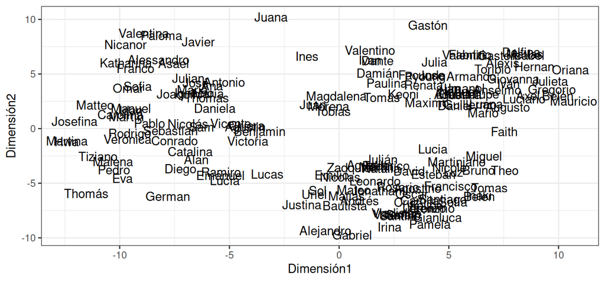

```
##          Límite Continuidad Derivada Extremos Integrales
## Josefina    R--           M       R-      B--          B
## Faith        R+         B--        R       R+         M+
```

## Mapa de similaridad (Componente 1 vs. Componente 2)

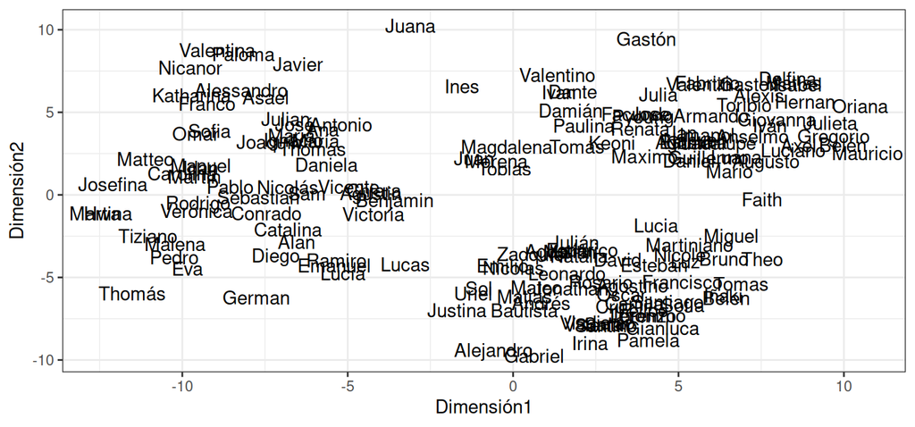

```
##           Límite Continuidad Derivada Extremos Integrales
## Gabriel        R          R-        B       B-         R-
## Valentino     M+         B--      R--       R-         R-
```

## Mapa de similaridad (Componente 1 vs. Componente 3)

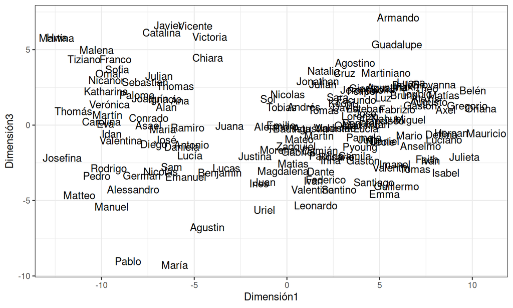

## Mapa de similaridad (Componente 2 vs. Componente 3)

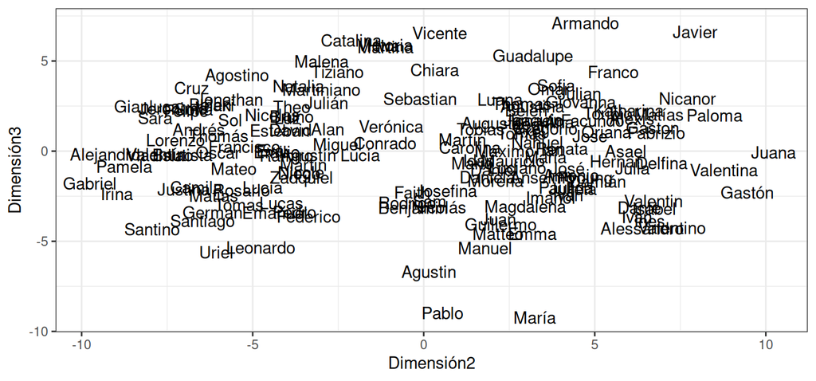

```
##         Límite Continuidad Derivada Extremos Integrales
## Pablo        M          R+        R       B-          B
## Vicente     R-          M+       R+      R--         R+
```

## Mapas similaridad (Integrales)

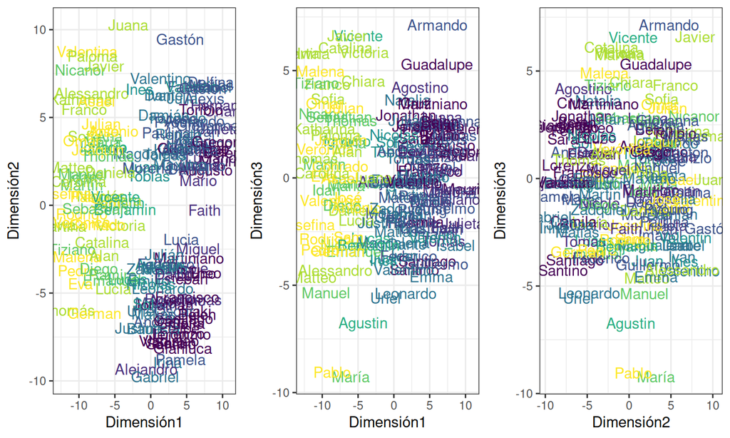

## Mapas similaridad (Derivada)

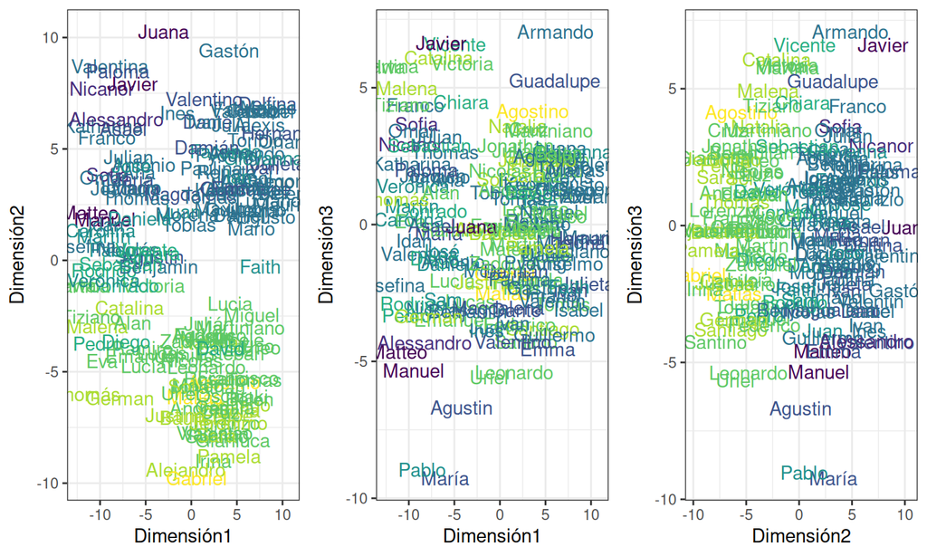

## STRESS

```r
mds_cat=isoMDS(dist_cat,k=2,trace=F);mds_cat$stress
```

```
## [1] 15.04434
```

```r
mds_cat=isoMDS(dist_cat,k=3,trace=F);mds_cat$stress
```

```
## [1] 10.76406
```

```r
mds_cat=isoMDS(dist_cat,k=4,trace=F);mds_cat$stress
```

```
## [1] 7.856351
```

```r
mds_cat=isoMDS(dist_cat,k=5,trace=F);mds_cat$stress
```

```
## [1] 6.259398
```